[Home](https://twitter.com/CanHolyavkin) | [Other Posts](https://twitter.com/CanHolyavkin) | [Contact](https://twitter.com/CanHolyavkin)

# RStudio’da

# Code Folding

RStudio, kod bölgeleri için otomatik ve kullanıcı tanımlı katlanmayı destekler. Kod katlama, kaynak dosyada gezinmeyi kolaylaştırmak ve kodlama görevine odaklanmak için kod bloklarını kolayca göstermenizi ve gizlemenizi sağlar. Örneğin, aşağıdaki kaynak dosyasında plot.autoregressive.model dosyasının gövdesi katlanmıştır:

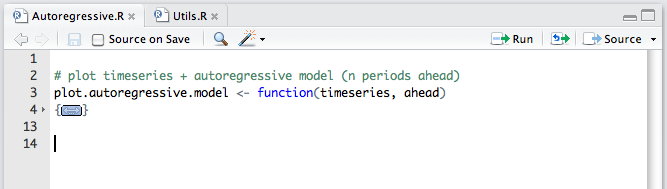

Katlanmış bölgeyi, oluktaki ok veya katlanmış kodun üzerine yazan simgeyi tıklayarak genişletebilirsiniz.

You can expand the folded region by either clicking on the arrow in the gutter or on the icon that overlays the folded code.

## Foldable Regions

You can also fold an arbitrary selection of code by using Edit -> Folding -> Collapse (Alt-L).

Folded regions are preserved while editing a document; however all foldable regions are shown expanded by default when a file is closed and re-opened.

# Code Sections

To insert a new code section you can use the Code -> Insert Section command. Alternatively, any comment line which includes at least four trailing dashes (-), equal signs (=), or pound signs (#) automatically creates a code section. For example, all of the following lines create code sections:

`# Section One ---------------------------------`  
`# Section Two =================================`  
`### Section Three #############################`

Note that as illustrated above the line can start with any number of pound signs (#) so long as it ends with four or more -, =, or # characters.

# Menu Commands and Shortcuts

The following menu commands and shortcuts are available for working with folded regions and code sections:

Edit -> Folding: Collapse — Alt+L Expand — Shift+Alt+L Collapse All — Alt+O Expand All — Shift+Alt+O Code: Insert Section — Ctrl+Shift+R (Cmd+Shift+R on the Mac) Jump To — Shift+Alt+J Note that the Collapse All command collapses all of the outermost foldable regions (rather than all of the nested regions within the source file).

**Can Holyavkin**

E-posta | [Linkedin](https://www.linkedin.com/in/can-holyavkin/) | [Twitter](https://twitter.com/CanHolyavkin)